# Telecom_Churn_Group_Case_Study

### Telecom Churn Case Study

- **Oorugonda Anusha**
- **Himabindu Srirangam**

###### Business Problem Overview

In the telecom industry, customers are able to choose from multiple service providers and actively switch from one operator to another. In this highly competitive market, the telecommunications industry experiences an average of 15-25% annual churn rate. Given the fact that it costs 5-10 times more to acquire a new customer than to retain an existing one, customer retention has now become even more important than customer acquisition.

For many incumbent operators, retaining high profitable customers is the number one business goal.

To reduce customer churn, telecom companies need to predict which customers are at high risk of churn.

In this project, you will analyse customer-level data of a leading telecom firm, build predictive models to identify customers at high risk of churn and identify the main indicators of churn.

###### Definitions of Churn

There are various ways to define churn, such as: 1. Revenue-based churn 2.Usage-based churn

For this project, you will use the **usage-based** definition to define churn.

**Usage-based churn:** Customers who have not done any usage, either incoming or outgoing - in terms of calls, internet etc. over a period of time. A potential shortcoming of this definition is that when the customer has stopped using the services for a while, it may be too late to take any corrective actions to retain them. For e.g., if you define churn based on a ‘two-months zero usage’ period, predicting churn could be useless since by that time the customer would have already switched to another operator.

###### business objective:

The business objective is to predict the churn in the last (i.e. the ninth) month using the data (features) from the first three months. To do this task well, understanding the typical customer behaviour during churn will be helpful.

The dataset contains customer-level information for a span of four consecutive months - June, July, August and September. The months are encoded as 6, 7, 8 and 9, respectively.

```python
# Ignoring warning messages
import warnings
warnings.filterwarnings('ignore')

# Import the required library
import numpy as np
import pandas as pd
import matplotlib.pyplot as plt
import seaborn as sns

pd.set_option('display.max_columns',230)
```

```python
churn_data= pd.read_csv('telecom_churn_data.csv')
churn_data.head()
```

|  | mobile_number | circle_id | loc_og_t2o_mou | std_og_t2o_mou | loc_ic_t2o_mou | last_date_of_month_6 | last_date_of_month_7 | last_date_of_month_8 | last_date_of_month_9 | arpu_6 | arpu_7 | arpu_8 | arpu_9 | onnet_mou_6 | onnet_mou_7 | onnet_mou_8 | onnet_mou_9 | offnet_mou_6 | offnet_mou_7 | offnet_mou_8 | offnet_mou_9 | roam_ic_mou_6 | roam_ic_mou_7 | roam_ic_mou_8 | roam_ic_mou_9 | roam_og_mou_6 | roam_og_mou_7 | roam_og_mou_8 | roam_og_mou_9 | … |
| --- | --- | --- | --- | --- | --- | --- | --- | --- | --- | --- | --- | --- | --- | --- | --- | --- | --- | --- | --- | --- | --- | --- | --- | --- | --- | --- | --- | --- | --- | --- |
| 0 | 7000842753 | 109 | 0.0 | 0.0 | 0.0 | 6/30/2014 | 7/31/2014 | 8/31/2014 | 9/30/2014 | 197.385 | 214.816 | 213.803 | 21.100 | NaN | NaN | 0.00 | NaN | NaN | NaN | 0.00 | NaN | NaN | NaN | 0.00 | NaN | NaN | NaN | 0.00 | NaN | … |
| 1 | 7001865778 | 109 | 0.0 | 0.0 | 0.0 | 6/30/2014 | 7/31/2014 | 8/31/2014 | 9/30/2014 | 34.047 | 355.074 | 268.321 | 86.285 | 24.11 | 78.68 | 7.68 | 18.34 | 15.74 | 99.84 | 304.76 | 53.76 | 0.0 | 0.00 | 0.00 | 0.00 | 0.0 | 0.00 | 0.00 | 0.00 | … |
| 2 | 7001625959 | 109 | 0.0 | 0.0 | 0.0 | 6/30/2014 | 7/31/2014 | 8/31/2014 | 9/30/2014 | 167.690 | 189.058 | 210.226 | 290.714 | 11.54 | 55.24 | 37.26 | 74.81 | 143.33 | 220.59 | 208.36 | 118.91 | 0.0 | 0.00 | 0.00 | 38.49 | 0.0 | 0.00 | 0.00 | 70.94 | … |
| 3 | 7001204172 | 109 | 0.0 | 0.0 | 0.0 | 6/30/2014 | 7/31/2014 | 8/31/2014 | 9/30/2014 | 221.338 | 251.102 | 508.054 | 389.500 | 99.91 | 54.39 | 310.98 | 241.71 | 123.31 | 109.01 | 71.68 | 113.54 | 0.0 | 54.86 | 44.38 | 0.00 | 0.0 | 28.09 | 39.04 | 0.00 | … |
| 4 | 7000142493 | 109 | 0.0 | 0.0 | 0.0 | 6/30/2014 | 7/31/2014 | 8/31/2014 | 9/30/2014 | 261.636 | 309.876 | 238.174 | 163.426 | 50.31 | 149.44 | 83.89 | 58.78 | 76.96 | 91.88 | 124.26 | 45.81 | 0.0 | 0.00 | 0.00 | 0.00 | 0.0 | 0.00 | 0.00 | 0.00 | … |

```python
churn_data.shape
```

```
(99999, 226)
```

```python
churn_data.info()
```

```
<class 'pandas.core.frame.DataFrame'>
RangeIndex: 99999 entries, 0 to 99998
Columns: 226 entries, mobile_number to sep_vbc_3g
dtypes: float64(179), int64(35), object(12)
memory usage: 172.4+ MB
```

```python
churn_data.describe()
```

|  | mobile_number | circle_id | loc_og_t2o_mou | std_og_t2o_mou | loc_ic_t2o_mou | arpu_6 | arpu_7 | arpu_8 | arpu_9 | onnet_mou_6 | onnet_mou_7 | onnet_mou_8 | onnet_mou_9 | offnet_mou_6 | offnet_mou_7 | offnet_mou_8 | offnet_mou_9 | roam_ic_mou_6 | roam_ic_mou_7 | roam_ic_mou_8 | roam_ic_mou_9 | roam_og_mou_6 | roam_og_mou_7 | roam_og_mou_8 | roam_og_mou_9 | loc_og_t2t_mou_6 | loc_og_t2t_mou_7 | loc_og_t2t_mou_8 | loc_og_t2t_mou_9 | … |
| --- | --- | --- | --- | --- | --- | --- | --- | --- | --- | --- | --- | --- | --- | --- | --- | --- | --- | --- | --- | --- | --- | --- | --- | --- | --- | --- | --- | --- | --- | --- |
| count | 9.999900e+04 | 99999.0 | 98981.0 | 98981.0 | 98981.0 | 99999.000000 | 99999.000000 | 99999.000000 | 99999.000000 | 96062.000000 | 96140.000000 | 94621.000000 | 92254.000000 | 96062.000000 | 96140.000000 | 94621.000000 | 92254.000000 | 96062.000000 | 96140.000000 | 94621.000000 | 92254.000000 | 96062.000000 | 96140.000000 | 94621.000000 | 92254.000000 | 96062.000000 | 96140.000000 | 94621.000000 | 92254.000000 | … |
| mean | 7.001207e+09 | 109.0 | 0.0 | 0.0 | 0.0 | 282.987358 | 278.536648 | 279.154731 | 261.645069 | 132.395875 | 133.670805 | 133.018098 | 130.302327 | 197.935577 | 197.045133 | 196.574803 | 190.337222 | 9.950013 | 7.149898 | 7.292981 | 6.343841 | 13.911337 | 9.818732 | 9.971890 | 8.555519 | 47.100763 | 46.473010 | 45.887806 | 44.584446 | … |
| std | 6.956694e+05 | 0.0 | 0.0 | 0.0 | 0.0 | 328.439770 | 338.156291 | 344.474791 | 341.998630 | 297.207406 | 308.794148 | 308.951589 | 308.477668 | 316.851613 | 325.862803 | 327.170662 | 319.396092 | 72.825411 | 73.447948 | 68.402466 | 57.137537 | 71.443196 | 58.455762 | 64.713221 | 58.438186 | 150.856393 | 155.318705 | 151.184830 | 147.995390 | … |
| min | 7.000000e+09 | 109.0 | 0.0 | 0.0 | 0.0 | -2258.709000 | -2014.045000 | -945.808000 | -1899.505000 | 0.000000 | 0.000000 | 0.000000 | 0.000000 | 0.000000 | 0.000000 | 0.000000 | 0.000000 | 0.000000 | 0.000000 | 0.000000 | 0.000000 | 0.000000 | 0.000000 | 0.000000 | 0.000000 | 0.000000 | 0.000000 | 0.000000 | 0.000000 | … |
| 25% | 7.000606e+09 | 109.0 | 0.0 | 0.0 | 0.0 | 93.411500 | 86.980500 | 84.126000 | 62.685000 | 7.380000 | 6.660000 | 6.460000 | 5.330000 | 34.730000 | 32.190000 | 31.630000 | 27.130000 | 0.000000 | 0.000000 | 0.000000 | 0.000000 | 0.000000 | 0.000000 | 0.000000 | 0.000000 | 1.660000 | 1.630000 | 1.600000 | 1.360000 | … |
| 50% | 7.001205e+09 | 109.0 | 0.0 | 0.0 | 0.0 | 197.704000 | 191.640000 | 192.080000 | 176.849000 | 34.310000 | 32.330000 | 32.360000 | 29.840000 | 96.310000 | 91.735000 | 92.140000 | 87.290000 | 0.000000 | 0.000000 | 0.000000 | 0.000000 | 0.000000 | 0.000000 | 0.000000 | 0.000000 | 11.910000 | 11.610000 | 11.730000 | 11.260000 | … |
| 75% | 7.001812e+09 | 109.0 | 0.0 | 0.0 | 0.0 | 371.060000 | 365.344500 | 369.370500 | 353.466500 | 118.740000 | 115.595000 | 115.860000 | 112.130000 | 231.860000 | 226.815000 | 228.260000 | 220.505000 | 0.000000 | 0.000000 | 0.000000 | 0.000000 | 0.000000 | 0.000000 | 0.000000 | 0.000000 | 40.960000 | 39.910000 | 40.110000 | 39.280000 | … |
| max | 7.002411e+09 | 109.0 | 0.0 | 0.0 | 0.0 | 27731.088000 | 35145.834000 | 33543.624000 | 38805.617000 | 7376.710000 | 8157.780000 | 10752.560000 | 10427.460000 | 8362.360000 | 9667.130000 | 14007.340000 | 10310.760000 | 13724.380000 | 15371.040000 | 13095.360000 | 8464.030000 | 3775.110000 | 2812.040000 | 5337.040000 | 4428.460000 | 6431.330000 | 7400.660000 | 10752.560000 | 10389.240000 | … |

```python
len(churn_data.mobile_number.unique())
```

```
99999
```

```python
churn_data.columns
```

```
Index(['mobile_number', 'circle_id', 'loc_og_t2o_mou', 'std_og_t2o_mou',
       'loc_ic_t2o_mou', 'last_date_of_month_6', 'last_date_of_month_7',
       'last_date_of_month_8', 'last_date_of_month_9', 'arpu_6',
       ...
       'sachet_3g_9', 'fb_user_6', 'fb_user_7', 'fb_user_8', 'fb_user_9',
       'aon', 'aug_vbc_3g', 'jul_vbc_3g', 'jun_vbc_3g', 'sep_vbc_3g'],
      dtype='object', length=226)
```

## 1. Data Cleaning

```python
def getMissingDataColumns(missingCutoff):
    missing = round(100*(churn_data.isnull().sum()/churn_data.shape[0]))
    print("There are {} features having more than {}% missing values/entries".format(len(missing.loc[missing > missingCutoff]),missingCutoff))
    return missing.loc[missing > missingCutoff]
```

```python
def imputeNan(data,imputeColList=False,missingColList=False):
    # Function impute the nan with 0
    # argument: colList, list of columns for which nan is to be replaced with 0
    if imputeColList:
        for col in [y + s for s in ['_6','_7','_8','_9'] for y in imputeColList]:
            data[col].fillna(0, inplace=True)
    else:
        for col in missingColList:
            data[col].fillna(0, inplace=True)
```

### Handling missing data

Let us check the missing data

```python
getMissingDataColumns(50)
```

```
There are 40 features having more than 50% missing values/entries
```

```
date_of_last_rech_data_6    75.0
date_of_last_rech_data_7    74.0
date_of_last_rech_data_8    74.0
date_of_last_rech_data_9    74.0
total_rech_data_6           75.0
total_rech_data_7           74.0
total_rech_data_8           74.0
total_rech_data_9           74.0
max_rech_data_6             75.0
max_rech_data_7             74.0
max_rech_data_8             74.0
max_rech_data_9             74.0
count_rech_2g_6             75.0
count_rech_2g_7             74.0
count_rech_2g_8             74.0
count_rech_2g_9             74.0
count_rech_3g_6             75.0
count_rech_3g_7             74.0
count_rech_3g_8             74.0
count_rech_3g_9             74.0
av_rech_amt_data_6          75.0
av_rech_amt_data_7          74.0
av_rech_amt_data_8          74.0
av_rech_amt_data_9          74.0
arpu_3g_6                   75.0
arpu_3g_7                   74.0
arpu_3g_8                   74.0
arpu_3g_9                   74.0
arpu_2g_6                   75.0
arpu_2g_7                   74.0
arpu_2g_8                   74.0
arpu_2g_9                   74.0
night_pck_user_6            75.0
night_pck_user_7            74.0
night_pck_user_8            74.0
night_pck_user_9            74.0
fb_user_6                   75.0
fb_user_7                   74.0
fb_user_8                   74.0
fb_user_9                   74.0
dtype: float64
```

#### From the above we see that there are 40 features having more that 50% missing values. Out of the 40 features many are essentials. The missing values for these features seems to suggest that these customers KPI's did not have any value at that month. We can choose to impute these values with 0.

Since av_rech_amt*data* *features are important for getting the high-value customers, lets impute the missing av_rech_amt*data** with 0

```python
imputeCol = ['av_rech_amt_data', 'arpu_2g', 'arpu_3g', 'count_rech_2g', 'count_rech_3g',
             'max_rech_data', 'total_rech_data','fb_user','night_pck_user']
imputeNan(churn_data,imputeCol)
```

```python
#Now let us again ssee the missing data above 50%
missingColumns = getMissingDataColumns(50)
missingColumns
```

```
There are 4 features having more than 50% missing values/entries
```

```
date_of_last_rech_data_6    75.0
date_of_last_rech_data_7    74.0
date_of_last_rech_data_8    74.0
date_of_last_rech_data_9    74.0
dtype: float64
```

We can drop these columns as these are of not much important

```python
missingColumns = list(getMissingDataColumns(50).index)
churn_data.drop(missingColumns, axis=1, inplace=True)
churn_data.shape
```

```
There are 4 features having more than 50% missing values/entries
```

```
(99999, 222)
```

```python
#Now let us try to get missing columns data for > 5%
getMissingDataColumns(5)
```

```
There are 29 features having more than 5% missing values/entries
```

```
onnet_mou_9         8.0
offnet_mou_9        8.0
roam_ic_mou_9       8.0
roam_og_mou_9       8.0
loc_og_t2t_mou_9    8.0
loc_og_t2m_mou_9    8.0
loc_og_t2f_mou_9    8.0
loc_og_t2c_mou_9    8.0
loc_og_mou_9        8.0
std_og_t2t_mou_9    8.0
std_og_t2m_mou_9    8.0
std_og_t2f_mou_9    8.0
std_og_t2c_mou_9    8.0
std_og_mou_9        8.0
isd_og_mou_9        8.0
spl_og_mou_9        8.0
og_others_9         8.0
loc_ic_t2t_mou_9    8.0
loc_ic_t2m_mou_9    8.0
loc_ic_t2f_mou_9    8.0
loc_ic_mou_9        8.0
std_ic_t2t_mou_9    8.0
std_ic_t2m_mou_9    8.0
std_ic_t2f_mou_9    8.0
std_ic_t2o_mou_9    8.0
std_ic_mou_9        8.0
spl_ic_mou_9        8.0
isd_ic_mou_9        8.0
ic_others_9         8.0
dtype: float64
```

From the above data we can see that all the features are from 9th month. Further let us check the customers are same for these missing data.

```python
missingColumns = list(getMissingDataColumns(5).index)
print ("There are %d customers having missing values for %s together"%(len(churn_data[churn_data[missingColumns].isnull().all(axis=1)]),missingColumns))
churn_data[churn_data[missingColumns].isnull().all(axis=1)][missingColumns].head()
```

```
There are 29 features having more than 5% missing values/entries
There are 7745 customers having missing values for ['onnet_mou_9', 'offnet_mou_9', 'roam_ic_mou_9', 'roam_og_mou_9', 'loc_og_t2t_mou_9', 'loc_og_t2m_mou_9', 'loc_og_t2f_mou_9', 'loc_og_t2c_mou_9', 'loc_og_mou_9', 'std_og_t2t_mou_9', 'std_og_t2m_mou_9', 'std_og_t2f_mou_9', 'std_og_t2c_mou_9', 'std_og…
```

|  | onnet_mou_9 | offnet_mou_9 | roam_ic_mou_9 | roam_og_mou_9 | loc_og_t2t_mou_9 | loc_og_t2m_mou_9 | loc_og_t2f_mou_9 | loc_og_t2c_mou_9 | loc_og_mou_9 | std_og_t2t_mou_9 | std_og_t2m_mou_9 | std_og_t2f_mou_9 | std_og_t2c_mou_9 | std_og_mou_9 | isd_og_mou_9 | spl_og_mou_9 | og_others_9 | loc_ic_t2t_mou_9 | loc_ic_t2m_mou_9 | loc_ic_t2f_mou_9 | loc_ic_mou_9 | std_ic_t2t_mou_9 | std_ic_t2m_mou_9 | std_ic_t2f_mou_9 | std_ic_t2o_mou_9 | std_ic_mou_9 | spl_ic_mou_9 | isd_ic_mou_9 | ic_others_9 |
| --- | --- | --- | --- | --- | --- | --- | --- | --- | --- | --- | --- | --- | --- | --- | --- | --- | --- | --- | --- | --- | --- | --- | --- | --- | --- | --- | --- | --- | --- |
| 0 | NaN | NaN | NaN | NaN | NaN | NaN | NaN | NaN | NaN | NaN | NaN | NaN | NaN | NaN | NaN | NaN | NaN | NaN | NaN | NaN | NaN | NaN | NaN | NaN | NaN | NaN | NaN | NaN | NaN |
| 7 | NaN | NaN | NaN | NaN | NaN | NaN | NaN | NaN | NaN | NaN | NaN | NaN | NaN | NaN | NaN | NaN | NaN | NaN | NaN | NaN | NaN | NaN | NaN | NaN | NaN | NaN | NaN | NaN | NaN |
| 29 | NaN | NaN | NaN | NaN | NaN | NaN | NaN | NaN | NaN | NaN | NaN | NaN | NaN | NaN | NaN | NaN | NaN | NaN | NaN | NaN | NaN | NaN | NaN | NaN | NaN | NaN | NaN | NaN | NaN |
| 32 | NaN | NaN | NaN | NaN | NaN | NaN | NaN | NaN | NaN | NaN | NaN | NaN | NaN | NaN | NaN | NaN | NaN | NaN | NaN | NaN | NaN | NaN | NaN | NaN | NaN | NaN | NaN | NaN | NaN |
| 35 | NaN | NaN | NaN | NaN | NaN | NaN | NaN | NaN | NaN | NaN | NaN | NaN | NaN | NaN | NaN | NaN | NaN | NaN | NaN | NaN | NaN | NaN | NaN | NaN | NaN | NaN | NaN | NaN | NaN |

Fromthe above list we can say that for all the 7745 customers the features are empty without any value, so we can choose to impute with 0

```python
imputeNan(churn_data,missingColList=missingColumns)
```

```python
churn_data=churn_data[~churn_data[missingColumns].isnull().all(axis=1)]
churn_data.shape
```

```
(99999, 222)
```

```python
#Now let us try to get missing columns data for > 2%
getMissingDataColumns(2)
```

```
There are 89 features having more than 2% missing values/entries
```

```
onnet_mou_6            4.0
onnet_mou_7            4.0
onnet_mou_8            5.0
offnet_mou_6           4.0
offnet_mou_7           4.0
                      ...
ic_others_6            4.0
ic_others_7            4.0
ic_others_8            5.0
date_of_last_rech_8    4.0
date_of_last_rech_9    5.0
Length: 89, dtype: float64
```

Further let us check the customers are same for these missing data.

```python
missingcolumns = list(getMissingDataColumns(2).index)
print ("There are %d customers having missing values for %s together"%(len(churn_data[churn_data[missingcolumns].isnull().all(axis=1)]),missingcolumns))
churn_data[churn_data[missingcolumns].isnull().all(axis=1)][missingcolumns].head()
```

```
There are 89 features having more than 2% missing values/entries
There are 381 customers having missing values for ['onnet_mou_6', 'onnet_mou_7', 'onnet_mou_8', 'offnet_mou_6', 'offnet_mou_7', 'offnet_mou_8', 'roam_ic_mou_6', 'roam_ic_mou_7', 'roam_ic_mou_8', 'roam_og_mou_6', 'roam_og_mou_7', 'roam_og_mou_8', 'loc_og_t2t_mou_6', 'loc_og_t2t_mou_7', 'loc_og_t2t_mo…
```

|  | onnet_mou_6 | onnet_mou_7 | onnet_mou_8 | offnet_mou_6 | offnet_mou_7 | offnet_mou_8 | roam_ic_mou_6 | roam_ic_mou_7 | roam_ic_mou_8 | roam_og_mou_6 | roam_og_mou_7 | roam_og_mou_8 | loc_og_t2t_mou_6 | loc_og_t2t_mou_7 | loc_og_t2t_mou_8 | loc_og_t2m_mou_6 | loc_og_t2m_mou_7 | loc_og_t2m_mou_8 | loc_og_t2f_mou_6 | loc_og_t2f_mou_7 | loc_og_t2f_mou_8 | loc_og_t2c_mou_6 | loc_og_t2c_mou_7 | loc_og_t2c_mou_8 | loc_og_mou_6 | loc_og_mou_7 | loc_og_mou_8 | std_og_t2t_mou_6 | std_og_t2t_mou_7 | … |
| --- | --- | --- | --- | --- | --- | --- | --- | --- | --- | --- | --- | --- | --- | --- | --- | --- | --- | --- | --- | --- | --- | --- | --- | --- | --- | --- | --- | --- | --- | --- |
| 202 | NaN | NaN | NaN | NaN | NaN | NaN | NaN | NaN | NaN | NaN | NaN | NaN | NaN | NaN | NaN | NaN | NaN | NaN | NaN | NaN | NaN | NaN | NaN | NaN | NaN | NaN | NaN | NaN | NaN | … |
| 275 | NaN | NaN | NaN | NaN | NaN | NaN | NaN | NaN | NaN | NaN | NaN | NaN | NaN | NaN | NaN | NaN | NaN | NaN | NaN | NaN | NaN | NaN | NaN | NaN | NaN | NaN | NaN | NaN | NaN | … |
| 687 | NaN | NaN | NaN | NaN | NaN | NaN | NaN | NaN | NaN | NaN | NaN | NaN | NaN | NaN | NaN | NaN | NaN | NaN | NaN | NaN | NaN | NaN | NaN | NaN | NaN | NaN | NaN | NaN | NaN | … |
| 1206 | NaN | NaN | NaN | NaN | NaN | NaN | NaN | NaN | NaN | NaN | NaN | NaN | NaN | NaN | NaN | NaN | NaN | NaN | NaN | NaN | NaN | NaN | NaN | NaN | NaN | NaN | NaN | NaN | NaN | … |
| 1232 | NaN | NaN | NaN | NaN | NaN | NaN | NaN | NaN | NaN | NaN | NaN | NaN | NaN | NaN | NaN | NaN | NaN | NaN | NaN | NaN | NaN | NaN | NaN | NaN | NaN | NaN | NaN | NaN | NaN | … |

From the above list 381 customers for all these features do not have any value. Let us remove these customers from the data.

```python
churn_data=churn_data[~churn_data[missingcolumns].isnull().all(axis=1)]
churn_data.shape
```

```
(99618, 222)
```

```python
# For other customers with these missing values, let's impute them with 0.
missingcolumns.remove('date_of_last_rech_8')
missingcolumns.remove('date_of_last_rech_9')
imputeNan(churn_data,missingColList=missingcolumns)
```

```python
#Now let us try to get missing columns data for > 0%
getMissingDataColumns(0)
```

```
There are 9 features having more than 0% missing values/entries
```

```
loc_og_t2o_mou          1.0
std_og_t2o_mou          1.0
loc_ic_t2o_mou          1.0
last_date_of_month_8    1.0
last_date_of_month_9    1.0
date_of_last_rech_6     1.0
date_of_last_rech_7     1.0
date_of_last_rech_8     3.0
date_of_last_rech_9     4.0
dtype: float64
```

```python
#let us check what are the unique values in these columns
columns = ['loc_og_t2o_mou','std_og_t2o_mou','loc_ic_t2o_mou','last_date_of_month_7','last_date_of_month_8','last_date_of_month_9', 'date_of_last_rech_6','date_of_last_rech_7', 'date_of_last_rech_8', 'date_of_last_rech_9']
print("unique values in these columns are : ")
for c in columns:
    print("for column: %s values are %s" % (c,churn_data[c].unique()))
```

```
unique values in these columns are :
for column: loc_og_t2o_mou values are [ 0. nan]
for column: std_og_t2o_mou values are [ 0. nan]
for column: loc_ic_t2o_mou values are [ 0. nan]
for column: last_date_of_month_7 values are ['7/31/2014' nan]
for column: last_date_of_month_8 values are ['8/31/2014' nan]
for column: last_date_of_month_9 values are ['9/30/2014' nan]
for column: date_of_last_rech_6 values are ['6/21/2014' '6/29/2014' '6/17/2014' '6/28/2014' '6/26/2014' '6/19/2014'
 '6/27/2014' '6/25/2014' '6/14/2014' '6/18/2014' '6/20/2014' '6/30/2014'
 '6/23/2014' nan '6/22/2014' '6/24/2014' '6/12/2014' '6/3/2014'
 '6/11/2014' '6/16/2014' '6/10/2014' '6/15/2014' '6/13/2014' '6/7/2014'
 '6/8/2014' '6/6/2014' '6/2/2014' '6/4/2014' '6/5/2014' '6/1/2014'
 '6/9/2014']
for column: date_of_last_rech_7 values are ['7/16/2014' '7/31/2014' '7/24/2014' '7/28/2014' '7/17/2014' '7/25/2014'
 '7/23/2014' '7/5/2014' '7/10/2014' '7/22/2014' '7/30/2014' '7/3/2014'
 '7/7/2014' '7/29/2014' '7/27/2014' '7/19/2014' '7/14/2014' '7/20/2014'
 '7/4/2014' '7/12/2014' nan '7/26/2014' '7/11/2014' '7/6/2014' '7/21/2014'
 '7/13/2014' '7/15/2014' '7/18/2014' '7/9/2014' '7/2/2014' '7/8/2014'
 '7/1/2014']
for column: date_of_last_rech_8 values are ['8/8/2014' '8/28/2014' '8/14/2014' '8/31/2014' '8/9/2014' '8/24/2014'
 '8/26/2014' '8/30/2014' '8/29/2014' '8/27/2014' '8/21/2014' '8/10/2014'
 '8/25/2014' '8/19/2014' '8/22/2014' '8/2/2014' '8/13/2014' '8/5/2014'
 '8/18/2014' '8/20/2014' '8/23/2014' '8/12/2014' '8/11/2014' '8/16/2014'
 '8/15/2014' '8/6/2014' nan '8/17/2014' '8/7/2014' '8/1/2014' '8/4/2014'
 '8/3/2014']
for column: date_of_last_rech_9 values are ['9/28/2014' '9/30/2014' '9/29/2014' '9/20/2014' '9/6/2014' nan
 '9/21/2014' '9/26/2014' '9/10/2014' '9/24/2014' '9/16/2014' '9/27/2014'
 '9/25/2014' '9/12/2014' '9/17/2014' '9/15/2014' '9/8/2014' '9/23/2014'
 '9/11/2014' '9/22/2014' '9/9/2014' '9/19/2014' '9/7/2014' '9/1/2014'
 '9/2/2014' '9/13/2014' '9/3/2014' '9/18/2014' '9/14/2014' '9/5/2014'
 '9/4/2014']
```

```python
# let us first treat those columns which take single value.
#All the below columns take only one value. Let us impute the missing values in these columns with the mode
columnswithsinglevalue = ['loc_og_t2o_mou','std_og_t2o_mou','loc_ic_t2o_mou','last_date_of_month_7','last_date_of_month_8','last_date_of_month_9']
for c in columnswithsinglevalue:
    print(churn_data[c].value_counts())
    churn_data[c].fillna(churn_data[c].mode()[0], inplace=True)
```

```
0.0    98981
Name: loc_og_t2o_mou, dtype: int64
0.0    98981
Name: std_og_t2o_mou, dtype: int64
0.0    98981
Name: loc_ic_t2o_mou, dtype: int64
7/31/2014    99300
Name: last_date_of_month_7, dtype: int64
8/31/2014    98867
Name: last_date_of_month_8, dtype: int64
9/30/2014    98321
Name: last_date_of_month_9, dtype: int64
```

```python
# now let us again get missing values > 0%
getMissingDataColumns(0)
```

```
There are 4 features having more than 0% missing values/entries
```

```
date_of_last_rech_6    1.0
date_of_last_rech_7    1.0
date_of_last_rech_8    3.0
date_of_last_rech_9    4.0
dtype: float64
```

```python
missingcolumns = list(getMissingDataColumns(0).index)
print ("There are %d rows in total having missing values for these variables."%(len(churn_data[churn_data[missingcolumns].isnull().all(axis=1)])))
churn_data[churn_data[missingcolumns].isnull().all(axis=1)][missingcolumns].head()
```

```
There are 4 features having more than 0% missing values/entries
There are 22 rows in total having missing values for these variables.
```

|  | date_of_last_rech_6 | date_of_last_rech_7 | date_of_last_rech_8 | date_of_last_rech_9 |
| --- | --- | --- | --- | --- |
| 4019 | NaN | NaN | NaN | NaN |
| 7344 | NaN | NaN | NaN | NaN |
| 8477 | NaN | NaN | NaN | NaN |
| 13358 | NaN | NaN | NaN | NaN |
| 14254 | NaN | NaN | NaN | NaN |

```python
# for these 4 columns let us have the values from the end month date
churn_data[churn_data['date_of_last_rech_6'].isnull()]['date_of_last_rech_6'] = '6/30/2014'
churn_data[churn_data['date_of_last_rech_7'].isnull()]['date_of_last_rech_7'] = '7/31/2014'
churn_data[churn_data['date_of_last_rech_8'].isnull()]['date_of_last_rech_8'] = '8/31/2014'
churn_data[churn_data['date_of_last_rech_9'].isnull()]['date_of_last_rech_9'] = '9/30/2014'
```

```python
#let us now look for customers  having all 0 values
zero_columns_values=churn_data.columns[(churn_data == 0).all()]
print ("There are {} features which has only 0 as values. These features are \n{}".format(len(zero_columns_values),zero_columns_values))
```

```
There are 11 features which has only 0 as values. These features are
Index(['loc_og_t2o_mou', 'std_og_t2o_mou', 'loc_ic_t2o_mou',
       'std_og_t2c_mou_6', 'std_og_t2c_mou_7', 'std_og_t2c_mou_8',
       'std_og_t2c_mou_9', 'std_ic_t2o_mou_6', 'std_ic_t2o_mou_7',
       'std_ic_t2o_mou_8', 'std_ic_t2o_mou_9'],
      dtype='object')
```

```python
# Let's remove these columns as well. as all take single value '0'.
churn_data.drop(zero_columns_values,axis=1,inplace=True)
```

```python
# Now let us find the percentage of data left after removing the missing values.
print("Percentage of data remaining after treating missing values: {}%".format(round(churn_data.shape[0]/99999 *100,2)))
print ("Number of customers: {}".format(churn_data.shape[0]))
print ("Number of features: {}".format(churn_data.shape[1]))
```

```
Percentage of data remaining after treating missing values: 99.62%
Number of customers: 99618
Number of features: 211
```

#### Fixing the data types and column names

Let us see the data types of different columns

```python
churn_data.reset_index(inplace=True,drop=True)
# list of all columns which store date
date_columns = list(churn_data.filter(regex='date').columns)
date_columns
```

```
['last_date_of_month_6',
 'last_date_of_month_7',
 'last_date_of_month_8',
 'last_date_of_month_9',
 'date_of_last_rech_6',
 'date_of_last_rech_7',
 'date_of_last_rech_8',
 'date_of_last_rech_9']
```

```python
# Converting dtype of date columns to datetime
for col in date_columns:
    churn_data[col] = pd.to_datetime(churn_data[col], format='%m/%d/%Y')
```

```python
churn_data.info()
```

```
<class 'pandas.core.frame.DataFrame'>
RangeIndex: 99618 entries, 0 to 99617
Columns: 211 entries, mobile_number to sep_vbc_3g
dtypes: datetime64[ns](8), float64(168), int64(35)
memory usage: 160.4 MB
```

#### Let us fix some column names which are not proper

##### There are some month columns whose names are not in proper month standards like (_6,_7,_8,_9). Let us fix them by renaming those columns

```python
churn_data.rename(columns={'jun_vbc_3g' : 'vbc_3g_6', 'jul_vbc_3g' : 'vbc_3g_7', 'aug_vbc_3g' : 'vbc_3g_8',
                      'sep_vbc_3g' : 'vbc_3g_9'}, inplace=True)
```

#### Creating new feature: 'vol_data_mb_6', 'vol_data_mb_7', 'vol_data_mb_8', 'vol_data_mb_9'

These will store the total data volume (= vol_2gmb + vol_3gmb) used by user.

```python
#Creating new feature: 'vol_data_mb_6', 'vol_data_mb_7', 'vol_data_mb_8', 'vol_data_mb_9',
for i in range(6,10):
    churn_data['vol_data_mb_'+str(i)] = (churn_data['vol_2g_mb_'+str(i)]+churn_data['vol_3g_mb_'+str(i)]).astype(int)
```

### Filter high-value customer

Those who have recharged with an amount more than or equal to X, where X is the 70th percentile of the average recharge amount in the first two months (the good phase).

```python
recharge_columns = churn_data.filter(regex=('count')).columns
churn_data[recharge_columns].head()
```

|  | count_rech_2g_6 | count_rech_2g_7 | count_rech_2g_8 | count_rech_2g_9 | count_rech_3g_6 | count_rech_3g_7 | count_rech_3g_8 | count_rech_3g_9 |
| --- | --- | --- | --- | --- | --- | --- | --- | --- |
| 0 | 0.0 | 0.0 | 0.0 | 0.0 | 1.0 | 1.0 | 1.0 | 0.0 |
| 1 | 0.0 | 1.0 | 2.0 | 0.0 | 0.0 | 0.0 | 0.0 | 0.0 |
| 2 | 0.0 | 0.0 | 0.0 | 1.0 | 0.0 | 0.0 | 0.0 | 0.0 |
| 3 | 0.0 | 0.0 | 0.0 | 0.0 | 0.0 | 0.0 | 0.0 | 0.0 |
| 4 | 1.0 | 0.0 | 0.0 | 0.0 | 0.0 | 0.0 | 0.0 | 0.0 |

**Creating new feature**:

- avg_rech_amt_6,avg_rech_amt_7,avg_rech_amt_8,avg_rech_amt_9 -

store the average recharge value for each customer for every month

```python
# Creating new feature: avg_rech_amt_6,avg_rech_amt_7,avg_rech_amt_8,avg_rech_amt_9
for i in range(6,10):
    churn_data['avg_rech_amt_'+str(i)] = round(churn_data['total_rech_amt_'+str(i)]/churn_data['total_rech_num_'+str(i)]+1,2)
```

```python
imputeNan(churn_data,missingColList=['avg_rech_amt_6','avg_rech_amt_7','avg_rech_amt_8','avg_rech_amt_9'])
```

**Creating new feature**:

- total_rech_num_data_6,total_rech_num_data_7,total_rech_num_data_8,total_rech_num_data_9

store the total number of data recharge (=count_rech_2g + count_rech_3g ) for each month.

```python
#Creating new feature: total_rech_num_data_6,total_rech_num_data_7,total_rech_num_data_8,total_rech_num_data_9
for i in range(6,10):
    churn_data['total_rech_num_data_'+str(i)] = (churn_data['count_rech_2g_'+str(i)]+churn_data['count_rech_3g_'+str(i)]).astype(int)
```

**Creating new feature**:

- total_rech_amt_data_6,total_rech_amt_data_7,total_rech_amt_data_8,total_rech_amt_data_9

store the total amount of data recharge (=total_rech_num_data * av_rech_amt_data ) for each month.

```python
#Creating new feature: total_rech_amt_data_6,total_rech_amt_data_7,total_rech_amt_data_8,total_rech_amt_data_9
for i in range(6,10):
    churn_data['total_rech_amt_data_'+str(i)] = churn_data['total_rech_num_data_'+str(i)]*churn_data['av_rech_amt_data_'+str(i)]
```

**Creating new feature**:

- total_month_rech_6,total_month_rech_7,total_month_rech_8,total_month_rech_9

store the total recharge amount (= total_rech_amt + total_rech_amt_data ) for each customer, for each month.

```python
#Creating new feature: total_mon_rech_6,total_mon_rech_7,total_mon_rech_8,total_mon_rech_9
for i in range(6,10):
    churn_data['total_month_rech_'+str(i)] = churn_data['total_rech_amt_'+str(i)]+churn_data['total_rech_amt_data_'+str(i)]
churn_data.filter(regex=('total_month_rech')).head()
```

|  | total_month_rech_6 | total_month_rech_7 | total_month_rech_8 | total_month_rech_9 |
| --- | --- | --- | --- | --- |
| 0 | 614.0 | 504.0 | 504.0 | 0.0 |
| 1 | 74.0 | 538.0 | 383.0 | 121.0 |
| 2 | 168.0 | 315.0 | 116.0 | 404.0 |
| 3 | 230.0 | 310.0 | 601.0 | 410.0 |
| 4 | 252.0 | 350.0 | 287.0 | 200.0 |

#### Let us calculate the average of first two months which is good phase total monthly recharge amount

```python
avg_goodPhase =(churn_data.total_month_rech_6 + churn_data.total_month_rech_7)/2

# finding the cutoff which is the 70th percentile of the good phase average recharge amounts
hv_cutoff= np.percentile(avg_goodPhase,70)

# Filtering the users whose good phase avg. recharge amount >= to the cutoff of 70th percentile.
hv_users = churn_data[avg_goodPhase >=  hv_cutoff]
hv_users.reset_index(inplace=True,drop=True)

print("Number of High-Value Customers in the Dataset: %d\n"% len(hv_users))
print("Percentage of High-value users in data : {}%".format(round(len(hv_users)/churn_data.shape[0]*100),2))
```

```
Number of High-Value Customers in the Dataset: 29906

Percentage of High-value users in data : 30%
```

#### Tagging Churners

Now tag the churned customers (churn=1, else 0) based on the fourth month as follows:

Those who have not made any calls (either incoming or outgoing) AND have not used mobile internet even once in the churn phase. The attributes we need to use to tag churners are:

- total_ic_mou_9
- total_og_mou_9
- vol_2g_mb_9
- vol_3g_mb_9

```python
# Function to tag customers as churners (churn=1, else 0) based on 'vol_2g_mb_','vol_3g_mb_','total_ic_mou_','total_og_mou_'
# argument: churnPhaseMonth, indicating the month number to be used to define churn (default= 9)
def getChurnStatus(data,churnPhaseMonth=9):
    churn_features= ['vol_2g_mb_','vol_3g_mb_','total_ic_mou_','total_og_mou_']
    flag = ~data[[s + str(churnPhaseMonth) for s in churn_features ]].any(axis=1)
    flag = flag.map({True:1, False:0})
    return flag
```

```python
hv_users['churn'] = getChurnStatus(hv_users,9)
print("There are {} users tagged as churners out of {} High-Value Customers.".format(len(hv_users[hv_users.churn == 1]),hv_users.shape[0]))
print("High-value Churn Percentage : {}%".format(round(len(hv_users[hv_users.churn == 1])/hv_users.shape[0] *100,2)))
```

```
There are 2418 users tagged as churners out of 29906 High-Value Customers.
High-value Churn Percentage : 8.09%
```

##### There are just 8.09% churn cases.

This indicated an highly imbalanced data set where the churn cases are the minority(8.09%) as opposed to the non-churners who are the majority(91.91)

## 2. Data Analysis

Let us plot some graphs for the features

```python
# Filtering the common monthly columns for each month
commonColumns = hv_users.filter(regex ='_6').columns
monthlyColumns = [item.strip('_6') for item in commonColumns]
monthlyColumns
```

```
['last_date_of_month',
 'arpu',
 'onnet_mou',
 'offnet_mou',
 'roam_ic_mou',
 'roam_og_mou',
 'loc_og_t2t_mou',
 'loc_og_t2m_mou',
 'loc_og_t2f_mou',
 'loc_og_t2c_mou',
 'loc_og_mou',
 'std_og_t2t_mou',
 'std_og_t2m_mou',
 'std_og_t2f_mou',
 'std_og_mou',
 'isd_og_mou',
 'spl_og_mou',
 'og_others',
 'total_og_mou',
 'loc_ic_t2t_mou',
 'loc_ic_t2m_mou',
 'loc_ic_t2f_mou',
 'loc_ic_mou',
 'std_ic_t2t_mou',
 'std_ic_t2m_mou',
 'std_ic_t2f_mou',
 'std_ic_mou',
 'total_ic_mou',
 'spl_ic_mou',
 'isd_ic_mou',
 'ic_others',
 'total_rech_num',
 'total_rech_amt',
 'max_rech_amt',
 'date_of_last_rech',
 'last_day_rch_amt',
 'total_rech_data',
 'max_rech_data',
 'count_rech_2g',
 'count_rech_3g',
 'av_rech_amt_data',
 'vol_2g_mb',
 'vol_3g_mb',
 'arpu_3g',
 'arpu_2g',
 'night_pck_user',
 'monthly_2g',
 'sachet_2g',
 'monthly_3g',
 'sachet_3g',
 'fb_user',
 'vbc_3g',
 'vol_data_mb',
 'avg_rech_amt',
 'total_rech_num_data',
 'total_rech_amt_data',
 'total_month_rech']
```

```python
# getting the number of monthly columns and profile columns
print ("Total number of columns in data :", hv_users.shape[1] )
print ("Number of columns for each month : ",len(monthlyColumns))
print ("Total monthly columns among the orignal columns (%d*4): %d"%(len(monthlyColumns), len(monthlyColumns) * 4))
print ("Columns other than monthly columns :", hv_users.shape[1] - (len(monthlyColumns) * 4))
```

```
Total number of columns in data : 232
Number of columns for each month :  57
Total monthly columns among the orignal columns (57*4): 228
Columns other than monthly columns : 4
```

```python
# Lets remove all the attributes corresponding to the churn phase i.e; all attributes having _9, etc. in their names.
col_9List = hv_users.filter(regex=('_9')).columns
hv_users.drop(col_9List,axis=1,inplace=True)
```

```python
# list of all the monthly columns 6,7,8,9
allmonthlyColumns = [x + s for s in ['_6','_7','_8'] for x in monthlyColumns]
allmonthlyColumns
```

```
['last_date_of_month_6',
 'arpu_6',
 'onnet_mou_6',
 'offnet_mou_6',
 'roam_ic_mou_6',
 'roam_og_mou_6',
 'loc_og_t2t_mou_6',
 'loc_og_t2m_mou_6',
 'loc_og_t2f_mou_6',
 'loc_og_t2c_mou_6',
 'loc_og_mou_6',
 'std_og_t2t_mou_6',
 'std_og_t2m_mou_6',
 'std_og_t2f_mou_6',
 'std_og_mou_6',
 'isd_og_mou_6',
 'spl_og_mou_6',
 'og_others_6',
 'total_og_mou_6',
 'loc_ic_t2t_mou_6',
 'loc_ic_t2m_mou_6',
 'loc_ic_t2f_mou_6',
 'loc_ic_mou_6',
 'std_ic_t2t_mou_6',
 'std_ic_t2m_mou_6',
 'std_ic_t2f_mou_6',
 'std_ic_mou_6',
 'total_ic_mou_6',
 'spl_ic_mou_6',
 'isd_ic_mou_6',
 'ic_others_6',
 'total_rech_num_6',
 'total_rech_amt_6',
 'max_rech_amt_6',
 'date_of_last_rech_6',
 'last_day_rch_amt_6',
 'total_rech_data_6',
 'max_rech_data_6',
 'count_rech_2g_6',
 'count_rech_3g_6',
```

[output cut: 116 more lines]

```
 'vol_3g_mb_8',
 'arpu_3g_8',
 'arpu_2g_8',
 'night_pck_user_8',
 'monthly_2g_8',
 'sachet_2g_8',
 'monthly_3g_8',
 'sachet_3g_8',
 'fb_user_8',
 'vbc_3g_8',
 'vol_data_mb_8',
 'avg_rech_amt_8',
 'total_rech_num_data_8',
 'total_rech_amt_data_8',
 'total_month_rech_8']
```

```python
# list of column which are not monthly columns
nonmonthlyColumns = [col for col in hv_users.columns if col not in allmonthlyColumns]
nonmonthlyColumns
```

```
['mobile_number', 'circle_id', 'aon', 'churn']
```

```python
# Getting the distinct circle_id's in the data
hv_users.circle_id.value_counts()
```

```
109    29906
Name: circle_id, dtype: int64
```

###### Looks like the data at hand is only for a single circle_id 109.

###### We can remove this feature going forward as it is not contributing to analysis and model building.

```python
hv_users.drop('circle_id',axis=1,inplace=True)
```

```
count    29906.000000
mean      1209.062396
std        957.342718
min        180.000000
25%        460.000000
50%        846.000000
75%       1755.000000
max       4321.000000
Name: aon, dtype: float64
```

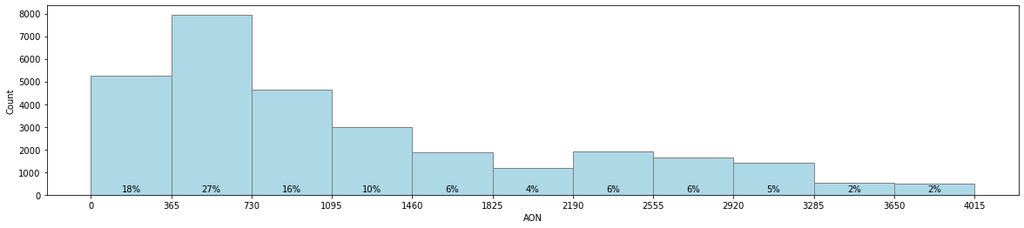

```python
# Customers distribution of the age on network (aon)
print(hv_users.aon.describe())
col = 'aon'
binsize = 365
dataset = hv_users

fig, ax = plt.subplots(figsize=(20,4))
counts, bins, patches = ax.hist(dataset[col],bins=range(0,dataset[col].max(),round(binsize)), facecolor='lightblue', edgecolor='gray')

# Set the ticks to be at the edges of the bins.
ax.set_xticks(bins)
bin_centers = 0.5 * np.diff(bins) + bins[:-1]
for count, x in zip(counts, bin_centers):
    # Label the percentages
    percent = '%0.0f%%' % (100 * float(count) / counts.sum())
    ax.annotate(percent, xy=(x,0.2), xycoords=('data', 'axes fraction'),
    xytext=(0, -32), textcoords='offset points', va='top', ha='center')

ax.set_xlabel(col.upper())
ax.set_ylabel('Count')
# Give ourselves some more room at the bottom of the plot
#plt.subplots_adjust(bottom=0.15)
plt.show()
```

- Minimun Age on network is 180 days.
- Average age on network for customers is 1200 days (3.2 years).
- 27% of the HV users are in their 2nd year with the network.
- Almost 71% users have Age on network less than 4 years.
- 15% users are with the network from over 7 years.

```python
#Create Derived categorical variable
hv_users['aon_bin'] = pd.cut(churn_data['aon'], range(0,churn_data['aon'].max(),365), labels=range(0,int(round(churn_data['aon'].max()/365))-1))
```

#### Incoming Vs Month Vs Age on Network (AON)

```python
def plot_avgMonthlyCalls(pltType,data,calltype,colList):
    # style
    plt.style.use('seaborn-darkgrid')
    # create a color palette
    palette = plt.get_cmap('Set2')

    if pltType == 'multi':
        #Create dataframe after grouping on AON with colList features
        total_call_mou = pd.DataFrame(data.groupby('aon_bin',as_index=False)[colList].mean())
        total_call_mou['aon_bin']=pd.to_numeric(total_call_mou['aon_bin'])
        total_call_mou
        # multiple line plot
        num=0
        fig, ax = plt.subplots(figsize=(15,8))
        for column in total_call_mou.drop('aon_bin', axis=1):
            num+=1
            ax.plot(total_call_mou['aon_bin'] , total_call_mou[column], marker='', color=palette(num), linewidth=2, alpha=0.9, label=column)

        ## Add legend
        plt.legend(loc=2, ncol=2)
        ax.set_xticks(total_call_mou['aon_bin'])

        # Add titles
        plt.title("Avg.Monthly "+calltype+" MOU  V/S AON", loc='left', fontsize=12, fontweight=0, color='orange')
        plt.xlabel("Aon (years)")
        plt.ylabel("Avg. Monthly "+calltype+" MOU")
    elif pltType == 'single':
        fig, ax = plt.subplots(figsize=(8,4))
        ax.plot(data[colList].mean())
        ax.set_xticklabels(['Jun','Jul','Aug','Sep'])

        # Add titles
        plt.title("Avg. "+calltype+" MOU  V/S Month", loc='left', fontsize=12, fontweight=0, color='orange')
        plt.xlabel("Month")
        plt.ylabel("Avg. "+calltype+" MOU")

    plt.show()
```

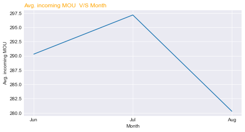

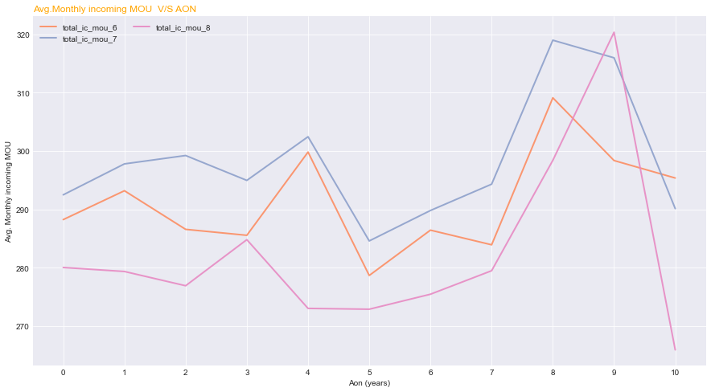

```python
# Plotting Avg. total monthly incoming MOU vs AON
ic_col = hv_users.filter(regex ='total_ic_mou').columns
plot_avgMonthlyCalls('single',hv_users,calltype='incoming',colList=ic_col)
plot_avgMonthlyCalls('multi',hv_users,calltype='incoming',colList=ic_col)
```

#### Outgoing VS month VS AON

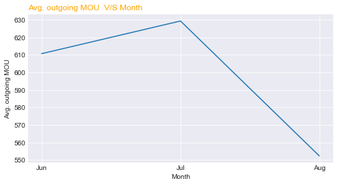

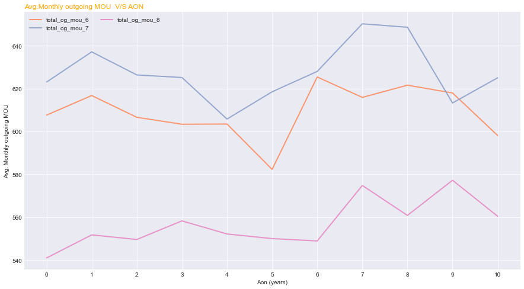

```python
# Plotting Avg. total monthly outgoing MOU vs AON
og_col = hv_users.filter(regex ='total_og_mou').columns
plot_avgMonthlyCalls('single',hv_users,calltype='outgoing',colList=og_col)
plot_avgMonthlyCalls('multi',hv_users,calltype='outgoing',colList=og_col)
```

#### Incoming/Outgoing MOU VS Churn

```python
def plot_byChurnMou(colList,calltype):
    fig, ax = plt.subplots(figsize=(7,4))
    df=hv_users.groupby(['churn'])[colList].mean().T
    plt.plot(df)
    ax.set_xticklabels(['Jun','Jul','Aug','Sep'])
    ## Add legend
    plt.legend(['Non-Churn', 'Churn'])
    # Add titles
    plt.title("Avg. "+calltype+" MOU  V/S Month", loc='left', fontsize=12, fontweight=0, color='orange')
    plt.xlabel("Month")
    plt.ylabel("Avg. "+calltype+" MOU")
```

```python
def plot_byChurn(data,col):
    # per month churn vs Non-Churn
    fig, ax = plt.subplots(figsize=(7,4))
    colList=list(data.filter(regex=(col)).columns)
    colList = colList[:3]
    plt.plot(hv_users.groupby('churn')[colList].mean().T)
    ax.set_xticklabels(['Jun','Jul','Aug','Sep'])
    ## Add legend
    plt.legend(['Non-Churn', 'Churn'])
    # Add titles
    plt.title( str(col) +" V/S Month", loc='left', fontsize=12, fontweight=0, color='orange')
    plt.xlabel("Month")
    plt.ylabel(col)
    plt.show()
    # Numeric stats for per month churn vs Non-Churn
    return hv_users.groupby('churn')[colList].mean()
```

```python
def plot_distribution(df, col):
    for i in range(6,9):
        fig, axes = plt.subplots(nrows=1, ncols=1,figsize=(12, 4))
        sns.boxplot(x='churn', y=col+'_'+str(i), data=df)
        sns.stripplot(x='churn', y=col+'_'+str(i), data=df, jitter=True, edgecolor="gray")
        plt.show()
```

```python
def plot_pairplot(df,col):
    sns.pairplot(data=df[[str(col)+'_6',str(col)+'_7',str(col)+'_8','churn']],hue='churn')
```

```python
# create plotting functions
def data_type(variable):
    if variable.dtype == np.int64 or variable.dtype == np.float64:
        return 'numerical'
    elif variable.dtype == 'category':
        return 'categorical'

def univariate(variable, stats=True):

    if data_type(variable) == 'numerical':
        sns.distplot(variable)
        if stats == True:
            print(variable.describe())

    elif data_type(variable) == 'categorical':
        sns.countplot(variable)
        if stats == True:
            print(variable.value_counts())

    else:
        print("Invalid variable passed: either pass a numeric variable or a categorical vairable.")
```

#### Incoming/Outgoing MOU VS Churn

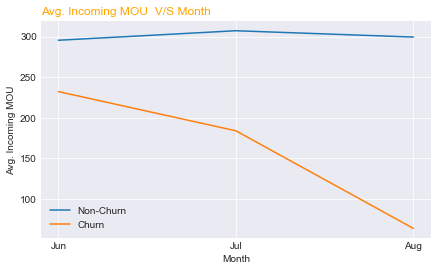

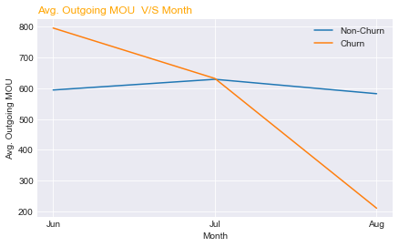

```python
ic_col = ['total_ic_mou_6','total_ic_mou_7','total_ic_mou_8']
og_col = ['total_og_mou_6','total_og_mou_7','total_og_mou_8']
plot_byChurnMou(ic_col,'Incoming')
plot_byChurnMou(og_col,'Outgoing')
```

From the above we can observe that

1. Churners Avg. Incoming/Outgoing MOU's drops drastically after the 2nd month,Jul.
2. While the non-churners Avg. MOU's remains consistant and stable with each month.
3. Therefore, users MOU is a key feature to predict churn.

Let's also see this trend in terms of actual numbers.

```python
# Avg.Incoming MOU per month churn vs Non-Churn
hv_users.groupby(['churn'])['total_ic_mou_6','total_ic_mou_7','total_ic_mou_8'].mean()
```

| churn | total_ic_mou_6 | total_ic_mou_7 | total_ic_mou_8 |
| --- | --- | --- | --- |
| 0 | 295.401726 | 307.108317 | 299.319664 |
| 1 | 232.221162 | 183.978888 | 63.813168 |

```python
# Avg. Outgoing MOU per month churn vs Non-Churn
hv_users.groupby(['churn'])['total_og_mou_6','total_og_mou_7','total_og_mou_8'].mean()
```

| churn | total_og_mou_6 | total_og_mou_7 | total_og_mou_8 |
| --- | --- | --- | --- |
| 0 | 594.414582 | 629.096568 | 582.380539 |
| 1 | 795.591038 | 631.859433 | 210.659326 |

#### Create new feature:

- og_to_ic_mou_6
- og_to_ic_mou_7
- og_to_ic_mou_8

These features will hold the ratio (=total_ogmou / total_icmou) for each month. These features will combine both incoming and outgoing informations and should be a better predictor of churn.

```python
#Creating new feature: og_to_ic_mou_6, og_to_ic_mou_7, og_to_ic_mou_8
# adding 1 to denominator to avoid dividing by 0 and getting nan values.
for i in range(6,9):
    hv_users['og_to_ic_mou_'+str(i)] = (hv_users['total_og_mou_'+str(i)])/(hv_users['total_ic_mou_'+str(i)]+1)
```

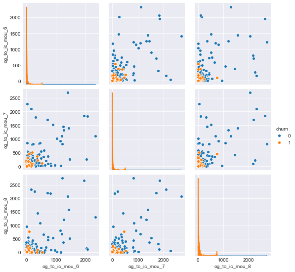

```python
#sns.pairplot(data=hv_users[['og_to_ic_mou_6','og_to_ic_mou_7','og_to_ic_mou_8','churn']], size=4,hue='churn')
plot_pairplot(hv_users, 'og_to_ic_mou')
```

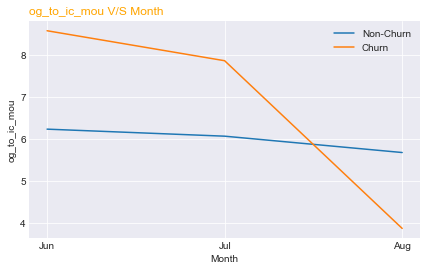

| churn | og_to_ic_mou_6 | og_to_ic_mou_7 | og_to_ic_mou_8 |
| --- | --- | --- | --- |
| 0 | 6.235602 | 6.067952 | 5.678424 |
| 1 | 8.580257 | 7.865938 | 3.870145 |

```python
plot_byChurn(hv_users,'og_to_ic_mou')
```

- Outgoing to incoming mou remains drops significantly for churners from month Jul(6) to Aug(7).
- While it remains almost consistent for the non-churners.

#### Create new feature:

- loc_og_to_ic_mou_6
- loc_og_to_ic_mou_7
- loc_og_to_ic_mou_8

These features will hold the ratio (=loc_ogmou / loc_icmou) for each month. These features will combine the local calls, both incoming and outgoing informations and should be a better predictor of churn.

```python
#Create new feature: loc_og_to_ic_mou_6, loc_og_to_ic_mou_7, loc_og_to_ic_mou_8
# adding 1 to denominator to avoid dividing by 0 and getting nan values.
for i in range(6,9):
    hv_users['loc_og_to_ic_mou_'+str(i)] = (hv_users['loc_og_mou_'+str(i)])/(hv_users['loc_ic_mou_'+str(i)]+1)
```

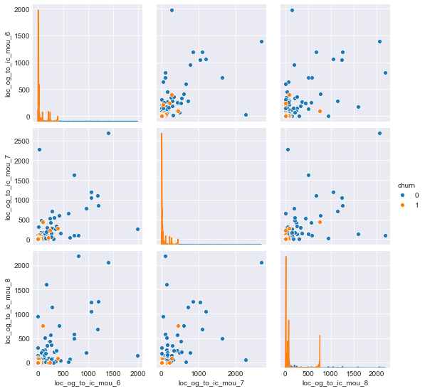

```python
plot_pairplot(hv_users, 'loc_og_to_ic_mou')
```

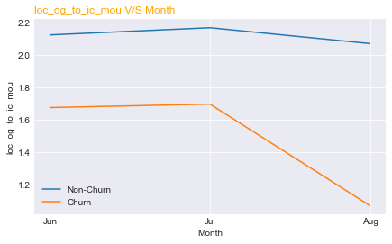

| churn | loc_og_to_ic_mou_6 | loc_og_to_ic_mou_7 | loc_og_to_ic_mou_8 |
| --- | --- | --- | --- |
| 0 | 2.124471 | 2.168763 | 2.070806 |
| 1 | 1.675413 | 1.696809 | 1.069765 |

```python
plot_byChurn(hv_users,'loc_og_to_ic_mou')
```

From the above we can observe that

- The local outgoing to incoming call mou ratio is genrally low for churners right from the begining of the good phase.
- local mou pattern for the non-churners remains almost constant through out the 3 months.
- The churners genrally show a low loc mou ratio but it drops dramatically after the 2nd month.
- This might suggest that people who are not making/reciving much local calls during their tenure are more likely to churn.

#### Total data volume VS Churn

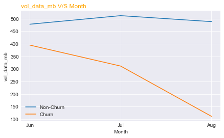

| churn | vol_data_mb_6 | vol_data_mb_7 | vol_data_mb_8 |
| --- | --- | --- | --- |
| 0 | 478.037762 | 512.164072 | 488.389661 |
| 1 | 394.949545 | 311.507444 | 111.469396 |

```python
plot_byChurn(hv_users,'vol_data_mb')
```

- The volume of data mb used drops significantly for churners from month Jul(6) to Aug(7).
- While it remains almost consistent for the non-churners.

#### Total monthly rech VS Churn

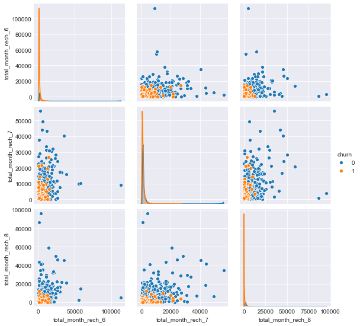

```python
plot_pairplot(hv_users, 'total_month_rech')
```

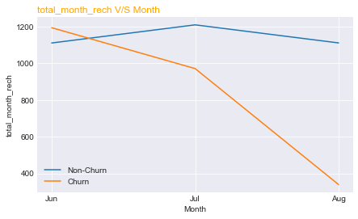

| churn | total_month_rech_6 | total_month_rech_7 | total_month_rech_8 |
| --- | --- | --- | --- |
| 0 | 1111.439977 | 1210.362853 | 1111.756912 |
| 1 | 1194.747593 | 971.802758 | 339.278974 |

```python
plot_byChurn(hv_users,'total_month_rech')
```

- total monthly rech amount also drops significantly for churners from month Jul(6) to Aug(7).
- While it remains almost consistent for the non-churners.

#### max_rech_amt VS Churn¶

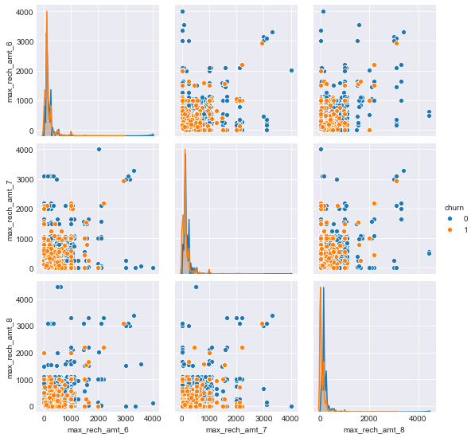

```python
plot_pairplot(hv_users, 'max_rech_amt')
```

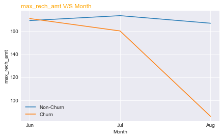

| churn | max_rech_amt_6 | max_rech_amt_7 | max_rech_amt_8 |
| --- | --- | --- | --- |
| 0 | 169.160943 | 173.437282 | 166.865250 |
| 1 | 170.930108 | 160.152192 | 86.026468 |

```python
plot_byChurn(hv_users,'max_rech_amt')
```

- maximum recharge amount also drops significantly for churners from month Jul(6) to Aug(7).
- While it remains almost consistent for the non-churners.

#### arpu (average revenue per user) VS Churn

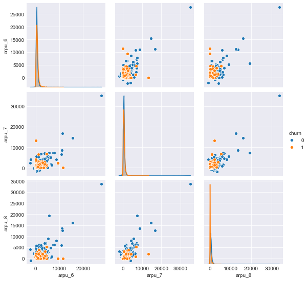

```python
plot_pairplot(hv_users, 'arpu')
```

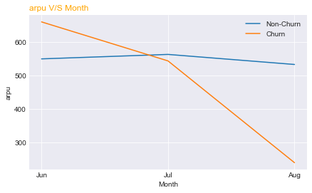

| churn | arpu_6 | arpu_7 | arpu_8 |
| --- | --- | --- | --- |
| 0 | 549.843524 | 563.190828 | 533.052496 |
| 1 | 660.695411 | 543.722952 | 238.631887 |

```python
plot_byChurn(hv_users,'arpu')
```

- Average revenue per user,arpu also drops significantly for churners from month Jul(6) to Aug(7).
- While it remains almost consistent for the non-churners.

#### Create new feature:

- Total_loc_mou_6
- Total_loc_mou_7
- Total_loc_mou_8

These features will hold the Total MOU (=loc_og_mou+loc_ic_mou) for each month. Using this we will find if the loc MOU (both incoming and outgoing) drops or increaces as the months goes by. This informations should be a better predictor of churn.

```python
#Create new feature: Total_loc_mou_6,Total_loc_mou_7,lTotal_loc_mou_8
for i in range(6,9):
    hv_users['Total_loc_mou_'+str(i)] = (hv_users['loc_og_mou_'+str(i)])+(hv_users['loc_ic_mou_'+str(i)])
```

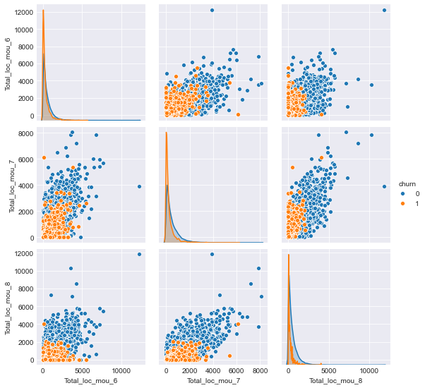

```python
plot_pairplot(hv_users, 'Total_loc_mou')
#sns.pairplot(data=hv_users[['Total_loc_mou_6','Total_loc_mou_7','Total_loc_mou_8','churn']],hue='churn')
```

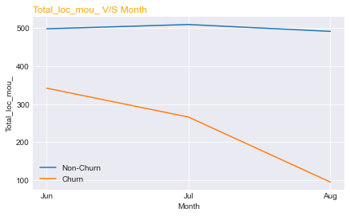

| churn | Total_loc_mou_6 | Total_loc_mou_7 | Total_loc_mou_8 |
| --- | --- | --- | --- |
| 0 | 498.548969 | 509.835211 | 491.705600 |
| 1 | 342.113462 | 266.025666 | 94.701154 |

```python
plot_byChurn(hv_users,'Total_loc_mou_')
```

From the above we can observe that

- The Total local call mou is genrally low for churners right from the begining of the good phase.
- local mou pattern for the non-churners remains almost constant through out the 3 months.
- The churners genrally show a low total loc mou but it drops dramatically after the 2nd month.
- This might suggest that people who are not making/reciving much local calls during their tenure are more likely to churn.

#### Create new feature:

- Total_roam_mou_6
- Total_roam_mou_7
- Total_roam_mou_8

These features will hold the Total roaming MOU (=roam_ic_mou+roam_og_mou) for each month. Using this we will find if the roam MOU (both incoming and outgoing) drops or increaces as the months goes by. This informations should be a better predictor of churn.

```python
#Create new feature: Total_roam_mou_6,Total_roam_mou_7,Total_roam_mou_8
for i in range(6,9):
    hv_users['Total_roam_mou_'+str(i)] = (hv_users['roam_ic_mou_'+str(i)])+(hv_users['roam_og_mou_'+str(i)])
```

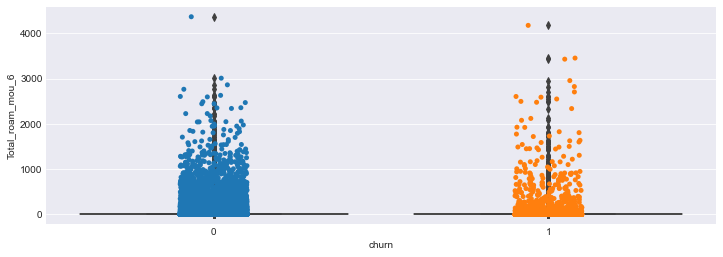

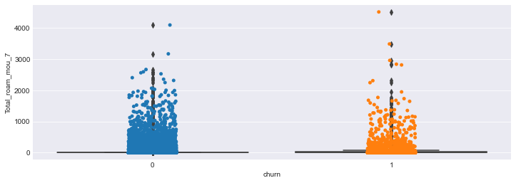

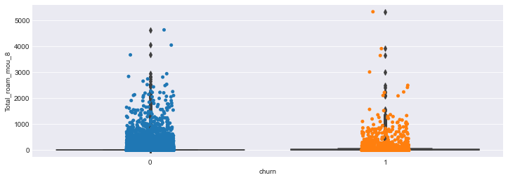

```python
plot_distribution(hv_users, 'Total_roam_mou')
```

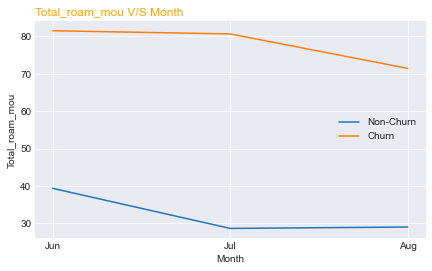

| churn | Total_roam_mou_6 | Total_roam_mou_7 | Total_roam_mou_8 |
| --- | --- | --- | --- |
| 0 | 39.360033 | 28.643301 | 29.016734 |
| 1 | 81.504156 | 80.651973 | 71.443623 |

```python
plot_byChurn(hv_users,'Total_roam_mou')
```

From the above we can observe that,

- Surprisingly, the roaming usage of churners is way higher than those of non-churners across all months
- People who are making/reciving more roaming calls during their tenure are more likely to churn.
- This might suggest that the operators roaming tariffs are higher than what are offered by its competitor, thus forming one of the reasons of churn.

#### last_day_rch_amt VS Churn

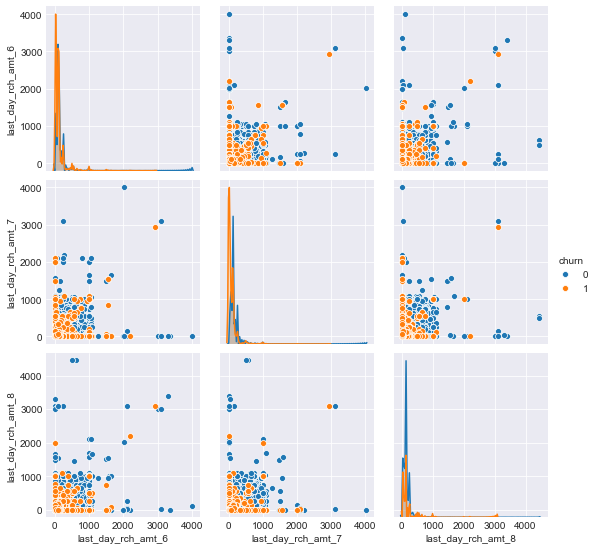

```python
plot_pairplot(hv_users, 'last_day_rch_amt')
```

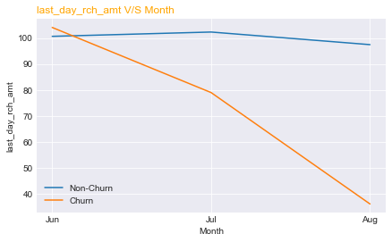

| churn | last_day_rch_amt_6 | last_day_rch_amt_7 | last_day_rch_amt_8 |
| --- | --- | --- | --- |
| 0 | 100.657232 | 102.318284 | 97.451724 |
| 1 | 104.085194 | 78.956989 | 35.955749 |

```python
plot_byChurn(hv_users,'last_day_rch_amt')
```

### Univariate EDA

```
count    29906.000000
mean       558.806269
std        460.374956
min      -2258.709000
25%        310.568500
50%        482.619000
75%        700.290750
max      27731.088000
Name: arpu_6, dtype: float64
```

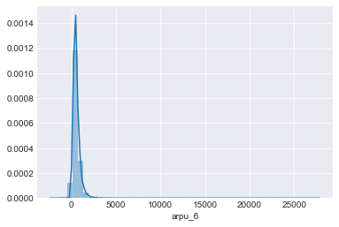

```python
univariate(hv_users.arpu_6)
```

```
count    29906.000000
mean       234.500335
std        458.952539
min          0.000000
25%         10.510000
50%         65.730000
75%        240.710000
max      10752.560000
Name: onnet_mou_8, dtype: float64
```

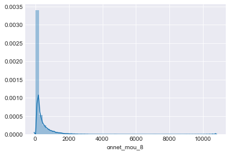

```python
univariate(hv_users.onnet_mou_8)
```